# script_DGE_python_Chapter10(13May20219 (1)

### Step 2: Initialization

In this step, we need to provide initial guesses of the steady state values of the aggregate capital stock $\tilde K$, labor $\tilde L$, mean working hours $\bar l$, labor income taxes $\tau^l$, the social security contribution rate $\tau^p$ and government transfers $\widetilde{tr}$. We assume that households work 30% of their time, $\bar l=0.30$. We also simply assume that aggregate efficient labor is also equal to $\tilde L=0.30$. Of course, this is only an approximation in our economy. On the one hand, only 78\% of the households are working. Since we normalize the total measure of households to one, $\tilde L$ should be lower for this reason. On the other hand, we observe that workers with higher productivity also work longer hours. Therefore, $\tilde L$ should be higher than the number of working hours. As it turns out, the result of our computation is insensitive with respect to the initial guesses; however, computational time until convergence to the final values may depend on our initial choice.

Using a real interest rate equal to $r=3\%$ and efficient labor supply $\tilde L=0.30$, we can compute the implied steady-state value of the capital stock from the first-order condition of the firm. Therefore, we have to define the functions 'wage(k,l)' and 'interest(k,l)' which compute the two factor prices of capital 'k' and aggregate efficient labor 'l'. For later use, we also set up the Cobb-Douglas production function 'production(k,l)'. We can solve the first-order condition of the firm with respect to capital for capital 'kbar' (corresponding to $\tilde K$ in the model) implying 'kbar=1.708'.

In our model, aggregate capital ('kbar'=1.708) is lower than aggregate savings, $\tilde K< \tilde \Omega$, as part of the savings is invested into government bonds $\tilde B$. In equilibrium, government bonds amount to 63% of GDP. Since the wealth-GDP ratio is approximately 3.0 in the United States, government bonds amount to approximately 21% of wealth and, hence, physical capital is approximately 79% of wealth. Therefore, we can get an initial guess for our wealth $\tilde \Omega$ by using the approximation $\tilde \Omega\approx 1.2 \tilde K$.

As for the final remaining aggregate quantities, we need to provide a guess for the pension contribution rate $\tau^p$ and government transfers $\tilde tr$. Given $\tilde K$ and $\tilde L$, we can compute the wage rate $w$ and, hence, pensions with the help of the replacement rate, $\widetilde{pen} = repl \times w \, \bar l$. With the help of the social security budget, we can provide a guess for $\tau^p$ (noticing that the measure of the retirees is equal to 'sum(mass[nw:nage]'. Given that $\tau^l+\tau^p=28\%$ in the US economy, we can also compute the labor income tax rate $\tau^l$, which is approximately equal to 20% in our initialization. For government transfers, we simply use a small number as initial guess, 'trbar=0.01'.

```python
def wage(k,l):
    return (1-alpha) * k**alpha * l**(-alpha)

# interest rate function
def interest(k,l):
    return alpha * k**(alpha - 1) * l**(1-alpha)

# production function
def production(k,l):
    return k**(alpha) * l**(1-alpha)

# initial guesses
#
rbar=0.03   # interest rate
nbar=0.3    # aggregate efficienct labor L
nold=100    # initialization
mean_labor=0.3   # average working hours
kbar=(alpha/(rbar+delta))**(1/(1-alpha))*nbar # capital stock
print(kbar)
kold=100    # initialization so that kold-kbar is larger than tolerance for outer loop
omega = kbar*1.2    # aggregate wealth
trbar=0.01          # transfers, initial guess
w=wage(kbar,nbar)
r=interest(kbar,nbar)
rb = (1-tauk)*(r-delta) # interest rate on bonds
pen=replacement_ratio*(1-taulbar)*w*mean_labor*sum(mass)/sum(mass[0:nw])
taup=pen*sum(mass[nw:nage])/sum(mass)/(w*nbar)  # balanced budet social security
taun = taulbar-taup
bequests=0
```

```
1.7080078856469167
```

### Step 3: Computation of the Optimal Policy Functions with (Finite) Value Function Iteration

Next, we introduce the optimization function which we apply to the right-hand side of the Bellman equation in the value function iteration. We will use Golden Section Search (as described in Section 11.6.1 in our book). The function is called using the command 'GoldenSectionMax(f,ay,by,cy,tol)' where f is a one-dimensional function, the maximum is bracketed by the points ay and cy, by is an intermediate point and tol describes the maximum difference between the upper and lower boundary, cy-ay. In the above parameterization of the program, we have chosen the tolerance 'tol1=1e-5'.

We use a simple function 'testfunc(x)' with the maximum at point x=2.0 to test our function GoldenSectionMax(.).

```python
# searches the MAXIMUM using golden section search
# see also Chapter 11.6.1 in Heer/Maussner, 2009,
# Dynamic General Equilibrium Modeling: Computational
# Methods and Applications, 2nd ed. (or later)
def GoldenSectionMax(f,ay,by,cy,tol):
    r1 = 0.61803399
    r2 = 1-r1
    x0 = ay
    x3 = cy
    if abs(cy-by) <= abs(by-ay):
        x1 = by
        x2 = by + r2 * (cy-by)
    else:
        x2 = by
        x1 = by - r2 * (by-ay)

    f1 = - f(x1)
    f2 = - f(x2)

    while abs(x3-x0) > tol*(abs(x1)+abs(x2)):
        if f2<f1:
            x0 = x1
            x1 = x2
            x2 = r1*x1+r2*x3
            f1 = f2
            f2 = -f(x2)
        else:
            x3 = x2
            x2 = x1
            x1 = r1*x2+r2*x0
            f2 = f1
            f1 = -f(x1)

    if f1 <= f2:
        xmin = x1
    else:
        xmin = x2

    return xmin

def testfunc(x):
    return -x**2 + 4*x + 6


# test goldensectionsearch
xmax = GoldenSectionMax(testfunc,-2.2,0.0,10.0,tol1)
print(xmax)
```

```
2.000001074862927
```

#### Value Function Iteration: Retirees

In the inner loop, we compute the policy functions of the worker and retiree using value function iteration. First, we initialize the value function of the retirees using the command 'vr = np.zeros((na,tr))', where the row index refers to the asset level $\tilde a$ and the column index to the 25 retirement ages $iage=s-nw=0,\ldots,24$.

To compute the value functions at retirement age $iage=0,\ldots,24$, we start in the last period and iterate backwards in time (or age). The value function in the last period of the life, $T=T^W+T^R=70$ with given exogenous pensions $\widetilde{pen}$ and interest rate $r$ is presented by

\begin{equation}\tilde V^{T}(\tilde a^{T}) = u(\tilde c^{T},1) \end{equation}

with

```python
# utility function
# utility with consumption c and labor l (=leisure 1-l)
def u(c,l):
    if eta==1:
        y =  gamma*log(c) +(1-gamma)*log(1-l)
    else:
        y = (c**(gamma*(1-eta)) *(1-l)**((1-gamma)*(1-eta))) / (1-eta)
    return y

# initialization of retiree's policy functions
vr=np.zeros((na,nr))    # value function with lump-sum pensions: only depends on assets a
aropt=np.zeros((na,nr))  # optimal asset
cropt=np.zeros((na,nr)) # optimal consumption

for ia in range(na):
    c = a[ia]*(1+(1-tauk)*(r-delta))+pen+trbar
    c = c/(1+tauc)
    vr[ia,nr-1] = u(c,0)
    cropt[ia,nr-1] = c
    aropt[ia,nr-1] = 0
```

In the next step, we consider the retiree in his second-to-last period at retirement age $iage=23$. We use Golden section search to compute the optimal solution to the right-hand side of the Bellman equation:

\begin{equation} \tilde v^{23}(\tilde a^{23}) = \max_{\tilde a^{24}} \left\{ u\left(\frac{\widetilde{pen} +[1+(1-\tau^k)(r-\delta)] \tilde a^{23}+ \widetilde{tr}- (1+g_A) \tilde a^{24}}{1+\tau^c},1 \right) + (1+g_A)^{\gamma (1-\eta)} \beta \; \tilde v^{24} (\tilde a^{24}) \right\}. \end{equation}

This basic step is performed in the program part below in the line

```
 aropt[ia,iage-1]=GoldenSectionMax(value1,ax,bx,cx,tol1)
```

The right-hand side of the Bellman equation which we are maximizing with respect to the choice of next-period assets $\tilde a'$ is specified in the function 'value1(x)'. In order to compute the right-hand side of the Bellman equation at age $s$, we need to evaluate the value function at age $s+1$ for the asset level $\tilde a'=x$. Since x may not be a grid point that we stored in the matrix 'vropt', we need to use interpolation to find the value. We use linear inteprolation, but you may change the method into 'cubic' as described above. We, therefore, apply the command 'interpolate.interp1d(a,vr[:,iage], kind='linear')'.

As a second input into the Golden Section Search Routine, we need to bracket the maximum by the interval $[ax,cx]$ with an intermediate value $bx$. We, therefore, start to search over the grid points $\tilde a_{ia}$ until the value of the rhs of the Bellman equation starts to decline. Therefore, we first initialize the value 'v0' with the value 'neg=-1e10' and adjust it whenever we find a higher value for the rhs of the Bellman equation with the help of $\tilde a_{ia}$. Once the rhs of the Bellman equation starts to decline, we know that we have bracket the maximum. Remember that the rhs of the Bellman equation is a concave function of $\tilde a'$.

We also make use of the monotonocity of the value function and the policy function $\tilde a'(.)$. Since both functions increase monotonically with $\tilde a$, we also speed up our algorithm when we search for $[ax,cx]$. Assume that we have found the lower boundary $ax$ for the grid point $\tilde a_{i_a}$. When we start searching for the lower boundary $ax$ for the next grid point, $\tilde a_{i_a+1}>\tilde a_{i_a}$, we simply start at the value of $ax$ found in the last iteration.

In the following computation, we also need to take special care if $ax$ ($cx$) happens to be the boundary point $\tilde a^{min}$ ($\tilde a^{max}$). In this case, we have to evaluate if we have a corner solution $\tilde a'=\tilde a^{min}$ ($\tilde a'=\tilde a^{max}$). For example, we compare the rhs of the Bellman equation at $\tilde a^{min}$ with the one evaluated at $\tilde a^{min}+eps$, where 'eps' is a small constant. If the value of 'value1()' at $\tilde a^{min}$ is larger than at $\tilde a^{min}+eps$, we have a corner solution. Otherwise, we may apply Golden Section search again.

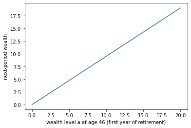

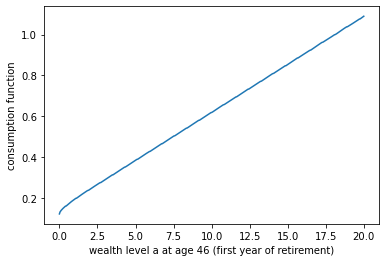

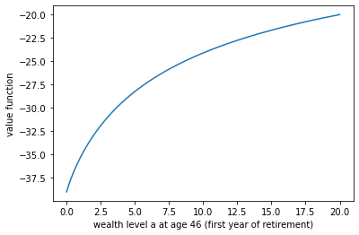

```python
# value function of retried with wealth a=a[ia] and a'=x
def value1(x):
    c = (1+(1-tauk)*(r-delta))*a[ia]+pen+trbar-ygrowth*x
    c = c/(1+tauc)
    if c<=0:
        return neg

    vr1 = vr_polate(x) # next-period value function at x
    y = u(c,0)+ygrowth**(gamma*(1-eta))*sp1[nw+iage-1]*beta1*vr1
    return y

for iage in range(nr-1,0,-1):
    # prepare interpolation function of the retiree's value function at age iage
    vr_polate = interpolate.interp1d(a,vr[:,iage], kind=kind_tol) # interpolation of vr at age iage+1
    for ia in range(na):
        ax=0
        bx=-1
        cx=-2
        v0=neg
        m=-1
        while ax>bx or bx>cx:
            m=m+1
            v1=value1(a[m])
            if v1>v0:
                if m==0:
                    ax=a[m]
                    bx=a[m]
                else:
                    bx=a[m]
                    ax=a[m-1];

                v0=v1
            else:
                cx=a[m]

            if m==na-1:
                ax=a[m-2]
                bx=a[m-1]
                cx=a[m-1]



        if ax==bx:  # check: a[1] is maximum point on grid?
            bx=ax+(a[1]-a[0])*eps
            if value1(ax)>value1(bx): # boundary solution
                aropt[ia,iage-1]=kmin # CHECK INDICES
            else:
                cx=a[1]
                aropt[ia,iage-1] = GoldenSectionMax(value1,ax,bx,cx,tol1)

        elif bx==cx: # check: a[na] is maximum point on grid?
            ax = a[na-2]
            cx = a[na-1]
            bx = a[na-1]-eps*(cx-ax)
            if value1(cx)>value1(bx):
                aropt[ia,iage-1] = a[na-1]
            else:
                aropt[ia,iage-1]=GoldenSectionMax(value1,ax,bx,cx,tol1)

        else:   # interior solution ax<bx<cx
            aropt[ia,iage-1]=GoldenSectionMax(value1,ax,bx,cx,tol1)


        vr[ia,iage-1]=value1(aropt[ia,iage-1])
        c = (1+(1-tauk)*(r-delta))*a[ia]+pen+trbar-ygrowth*aropt[ia,iage-1]
        cropt[ia,iage-1] = c/(1+tauc)

plt.xlabel('wealth level a at age 46 (first year of retirement)')
plt.ylabel('next-period wealth')
plt.plot(a,aropt[:,0])
plt.show()

plt.xlabel('wealth level a at age 46 (first year of retirement)')
plt.ylabel('consumption function')
plt.plot(a,cropt[:,0])
plt.show()

plt.xlabel('wealth level a at age 46 (first year of retirement)')
plt.ylabel('value function')
plt.plot(a,vr[:,0])
plt.show()
```

The value and policy functions of the 46-year old (first period of retirement) are displayed above. Notice that all three functions $\tilde a'(.)$, $\tilde c(.)$ and $\tilde v(.)$ are monotone functions and that $\tilde v(.)$ is concave.

#### Value Function Iteration of the Worker

Next, we turn to the value function iteration of the worker. The procedure is almost the same as in the case of the retiree. The worker also maximizes the right-hand side of the Bellman equation. However, different from the retiree, he also chooses optimal labor supply.

There are different ways how we can implement this two-dimensional optimization problem. We have choosen to break it up in two nested optimization problems. In the outer loop, we optimize over the next-period wealth $a'$ just like in the case of the retiree. The Golden Section Search algorithm maximizes the value function 'value2(x)' of the worker where the argument $x$ of the function is the next-period wealth level $\tilde a'$. In the inner loop (inside the function 'value2(x)'), we compute the optimal labor supply given this and next-period wealth, $\tilde a$ and $\tilde a'$ using the first-order condition of the worker with respect to his labor supply:

\begin{equation} \frac{(1-\tau^l-\tau^p) \epsilon(s,\theta,e) w}{1+\tau^c} = \frac{1-\gamma}{\gamma} \frac{\tilde c}{1-l}. \end{equation}

After the substition of $\tilde c$ from the budget constraint of the worker, we can solve for the labor supply $l$ of the worker:

\begin{equation} l = \gamma - \frac{1-\gamma}{(1-\tau^l-\tau^p) \epsilon(s,\theta,e)w} \left( \left[ 1+(1-\tau^k)(r-\delta) \right]\tilde a +\widetilde{tr}-(1+g_A) \tilde a' \right) \end{equation}

We also have to impose the constraint $l\ge 0$ and $l \le 0.60$ if $l$ happens to lie outside the admissible space.

Notice that, in the present case, it is easy to compute the optimal labor supply since we can solve for $l$ explicitly. If we use a different utility function or consider contributions-based pensions, labor supply may only be computed implicitly and we have to use more sophisticated methods. In the case of a different utility function, we may have to solve a non-linear equation problem. If we also consider contributions-based pensions, the computation of the optimal labor supply is more complicated and we will discuss it in the next section of our book.

The implementation of this nested optimization is straightforward. The function 'value2(x)' computes the right-hand side of the Bellman equation for next-period wealth $\tilde a'=x$. The present period wealth is given by the global variable 'k0'. We also use the productivity type $\epsilon(s,\theta,e)$ as given by the global variables 'perm[iperm]', 'ye1[iy]' and 'ef[s]'. With the help of these variables, $\tilde a'$ and $\tilde a$, and the factor prices $w$ and $r$, we are able to compute the optimal labor supply $l$. We also have to check if $l\ge 0$ and $l\le 0.60$. If not, we set it either equal to zero, $l=0$, or $l=0.60$. In order to compute the Bellman equation, we also have to determine the value of the next-period value function at age $i+1$ and wealth $x=\tilde a'$. We again interpolate either linearly or with a cubic spline. Notice that at age $s=45$ (corresponding to $iage=44$ in the iteration over the age of the worker), the next-period value function is the value function of the retiree during his first period of retirement. In this case, we have to interpolate 'vw0=vr[:,0]''; otherwise, the next-period value function is given by 'vw0=vw[:,iage+1]''.

In the outer loop, we just use golden section search with respect to next-period wealth $\tilde a'$. This is implemented in the line

'k1 = GoldenSectionMax(value2,ax,bx,cx,tol1)'

Again, we have to bracket the maximum by the interval $[ax,cx]$ and have to take special care with the boundary points $\tilde a^{min}$ and $\tilde a^{max}$ just like in the case with the retired agent.

The value function of the worker at ages $iage=44,\ldots,0$ is computed in the next part of the program:

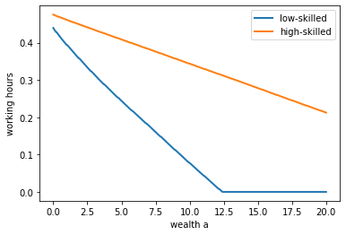

```python
# computes the optimal labor supply
# for wealth level a0 at age s and a1 at age s+1
def optimal_labor(a0,a1):
    w0=(1-taun-taup)*w*ef[iage]*perm[iperm]*ye1[iy]
    labor = gamma - ((1+(1-tauk)*(r-delta))*a0+trbar-ygrowth*a1)*(1-gamma)/w0
    return labor
# value function of worker with wealth a=a[ia]
def value2(x):
    k0 = a[ia]
    k1 = x

    # solving directly for optimal labor supply
    labor = optimal_labor(k0,k1)
    # alternative solution: non-linear eq. system
    # labor = scipy.optimize.fsolve(findl, laborinitial, args=(k0,k1))

    if labor<0:
        labor=0

    if labor>labormax:
        labor=labormax

    w0 = w*ef[iage]*ye1[iy]*perm[iperm]
    c=(1+(1-tauk)*(r-delta))*k0+(1-taun-taup)*w0*labor+trbar-ygrowth*x
    c=c/(1+tauc)
    if c<=0:
        return neg

    if iage==nw-1:
        vr_polate = interpolate.interp1d(a,vr[:,0], kind=kind_tol)
        y = u(c,labor)+ygrowth**(gamma*(1-eta))*sp1[iage]*beta1*vr_polate(k1)
    else:
        y = u(c,labor)
        for iy1 in range(ny):
            # interpolation of vw at age iage in the next period of life
            vw_polate = interpolate.interp1d(a,vw[:,iy1,iperm,iage+1], kind=kind_tol)
            y = y + py[iy,iy1]*ygrowth**(gamma*(1-eta))*sp1[iage]*beta1*vw_polate(x)
    return y

# workers' value function
vw = np.zeros((na,ny,nperm,nw))
awopt = np.zeros((na,ny,nperm,nw))
lopt = np.zeros((na,ny,nperm,nw))
cwopt = np.zeros((na,ny,nperm,nw))

for iage in range(nw-1,-1,-1):
    # print(iage)
    for iperm in range(nperm):
        # print(iperm)

        for iy in range(ny):
            m0=-1
            for ia in range(na):
                k0 = a[ia]

                # triple ax,bx,cx
                ax=0
                bx=-1
                cx=-2
                v0=neg
                m=m0
                while ax>bx or bx>cx:
                    m=m+1
                    v1=value2(a[m])

                    if v1>v0:
                        m0=max(-1,m-2) # monotonocity in a'(a)
                        if m==0:
                            ax=a[m]
                            bx=a[m]
                        else:
                            bx=a[m]
                            ax=a[m-1]

                        v0=v1
                    else:
                        cx=a[m]

                    if m==na-1:
                        ax=a[m-1]
                        bx=a[m]
                        cx=a[m]



                if ax==bx:  # boundary optimum, ax=bx=a[0]
                    bx=ax+eps*(a[1]-a[0])
                    if value2(bx)<value2(ax):
                        k1=a[0]
                    else:
                        k1 = GoldenSectionMax(value2,ax,bx,cx,tol1)

                elif bx==cx: # boundary solution at bx=cx=a[na-1]
                    bx=cx-eps*(a[na-1]-a[na-2])
                    if value2(bx)<value2(cx):
                        k1 = a[na-1]
                    else:
                        k1 = GoldenSectionMax(value2,ax,bx,cx,tol1)

                else:
                    k1 = GoldenSectionMax(value2,ax,bx,cx,tol1)



                awopt[ia,iy,iperm,iage]=k1
                labor = optimal_labor(k0,k1)
                # alternatively you may use the solution to a non-linear eq. problem
                # -> more time-consuming, but sometimes necessary if we cannot solve for labor
                #
                # labor = scipy.optimize.fsolve(findl, laborinitial, args=(k0,k1))
                # if abs(findl(labor,k0,k1))>tol:


                if labor<0:
                    labor=0

                if labor>labormax:
                    labor=labormax


                lopt[ia,iy,iperm,iage]=labor
                w0 = w*ef[iage]*ye1[iy]*perm[iperm]
                c =(1+(1-tauk)*(r-delta))*k0
                c =c+(1-taun-taup)*w0*labor+trbar-ygrowth*k1
                c =c/(1+tauc)

                vw[ia,iy,iperm,iage] = value2(k1)
                cwopt[ia,iy,iperm,iage] = c

# save results
np.save('vw',vw)
np.save('vr',vr)
np.save('cwopt',cwopt)
np.save('cropt',cropt)
np.save('awopt',awopt)
np.save('aropt',aropt)
np.save('lopt',lopt)

# plot results
iage0 = 20
iy0 = 3
fig, ax = plt.subplots()
label1 = 'low-skilled'
label2 = 'high-skilled'
plt.xlabel('wealth a')
plt.ylabel('working hours')
ax.plot(a,lopt[:,iy0,0,iage0], linewidth=2, label=label1)
ax.plot(a,lopt[:,iy0,1,iage0], linewidth=2, label=label2)
ax.legend()
plt.show()
```

It is always good idea to plot the policy function for some different productivity types and ages (remember that the number of all productivities and ages of the workers alone amounts to $nperm \times ny \times nw = 450$). Therefore, we need to restrict our attention to the study of a random choice. Above, we graph the labor supply function of the skilled and unskilled worker at age $s=21$ with mean idosyncratic productivity $iy=3$ (corresponding to $\theta=0.378$). Labor supply falls with higher wealth $\tilde a$. The high-skilled (orange curve) has a much higher labor supply than the low-skilled (blue curve) for given wealth $\tilde a$ (but since the high-skilled holds higher wealth, the difference in observed working hours is smaller). In addition, the lower boundary $l\ge 0$ starts binding for the low-skilled worker for a wealth level in excess of 12.0.

##### Euler equation residual

To evaluate the accuracy of our policy function approximation, we study the so-called 'Euler residual' which is defined as the percentage deviation of the Euler equation. (The Euler residual is considered in many chapters of our book on 'Dynamic General Equilibrium Modeling', for example in Chapter 6 where we consider projection methods.) For the $s$-year old worker with wealth level $\tilde a$ and productivity type $\epsilon(s,\theta,e)$, the Euler equation residual is defined by:

\begin{equation} R(\tilde a) = 1 - \frac{\tilde u_c(\tilde c,l)}{\beta \phi^s \mathbb{E} \left\{\tilde u_c(\tilde c',l')\right\}}, \end{equation}

where $\tilde c'$ and $l'$ are next-period consumption level and labor supply and expectations $\mathbb{E}$ are conditional on information at age $s$ in period $t$ (after observing the productivity shock in this period).

If $R(\tilde a)=0$, the Euler equation error is zero and we have a perfect fit. The Euler equation residual is a popular measure of accuracy. In particular, Watson (2000, 'Accuracy of Numerical Solutions using the Euler Equation Residuals', Econometrica) has shown that the accuracy of the numerical approximation of the policy function is of the same order of magnitude as the numerical error of the Euler equation residual.

Therefore, we evaluate the Euler equation error in the following to get an idea about the goodness of fit. We use a finer grid of the asset level for the Euler equation residual than that for the policy function. We want to consider points off the policy function grid where we have to interpolate between grid points and accuracy might be smaller. As our measure of fit we use the average absolute Euler equation residual.

In order to compute the Euler equation error, we also need to define functions for the marginal utility of consumption for the present and the next period, $uc(.)$ and $uc1(.)$ in our Python code. The evaluation of next-period marginal utility is very time-consuming because we need to interpolate the next-period policy functions (stored in 'cwopt' and 'lopt') to derive $c'$ and $l'$. Therefore, you should compute the Euler residual only when you develop the program to check for the accuracy of your computer code and after the final outer loop over the aggregate variables when you want to determine if the number of grid points and the mode of interpolation is sufficient.

```python
# marginal utility from consumption
def uc(c,l):
	y = gamma*c**(gamma*(1-eta)-1) * (1-l)**((1-gamma)*(1-eta))
	return y

# marginal utility from consumption next period given a',iperm,iy1,iage1
# in next period
def uc1(a1,iperm,iy1,iage1):
    if iage1<=nw-1:
        if a1<=kmin:
            c1 = cwopt[0,iy1,iperm,iage1]
            labor = lopt[0,iy1,iperm,iage1]
        elif a1>=kmax:
            c1 = cwopt[na-1,iy1,iperm,iage1]
            labor =  lopt[na-1,iy1,iperm,iage1]
        else:
            c_polate = interpolate.interp1d(a,cwopt[:,iy1,iperm,iage1], kind=kind_tol)
            c1 = c_polate(a1)
            l_polate = interpolate.interp1d(a,lopt[:,iy1,iperm,iage1], kind=kind_tol)
            labor = l_polate(a1)
    else:
        labor = 0
        if a1<=kmin:
            c1 = cropt[0,iage1-nw]
        elif a1>=kmax:
            c1 = cropt[na-1,iage1-nw];
        else:
            c_polate = interpolate.interp1d(a,cropt[:,iage1-nw], kind=kind_tol)
            c1 = c_polate(a1)

    y = uc(c1,labor)
    return y




# Residual: Euler equation
# compute the residuals of the first-order and Euler eqs
# to check for accuracy of value function iteration and interpolation method
Euler_res = np.zeros((nag,ny,nperm,nw))
Euler_res_old = np.zeros((nag,nr-1))

for iage in range(nw):
    # print(iage)
    for iperm in range(nperm):
        for iy in range(ny):
            for iag in range(nag):
                if ag[iag]<=kmin:
                    k1=awopt[0,iy,iperm,iage]
                    labor=lopt[0,iy,iperm,iage]
                    c = cwopt[0,iy,iperm,iage]
                elif ag[iag]>=kmax:
                    k1=awopt[na-1,iy,iperm,iage]
                    labor=lopt[na-1,iy,iperm,iage]
                    c = cwopt[na-1,iy,iperm,iage]
                else:   # linear interpolation between grid points
                    aw_polate = interpolate.interp1d(a,awopt[:,iy,iperm,iage], kind=kind_tol)
                    k1 = aw_polate(ag[iag])
                    c_polate = interpolate.interp1d(a,cwopt[:,iy,iperm,iage], kind=kind_tol)
                    c = c_polate(ag[iag])
                    l_polate = interpolate.interp1d(a,lopt[:,iy,iperm,iage], kind=kind_tol)
                    labor = l_polate(ag[iag])

                # computation of the Euler residual
                #
                # (1+g_A)^eta u_{c,t} = beta phi^i E_t{ u_{c,t+1} [1+(1-tauk) (r-delta)] }
                #

                x=0
                if iage<nw-1:
                    for iy1 in range(ny):
                        x = x+beta1*sp1[iage]*py[iy,iy1]*(1+rb)*uc1(k1,iperm,iy1,iage+1)
                else:
                    x = beta1*sp1[iage]*uc1(k1,iperm,iy1,iage+1)

                Euler_res[iag,iy,iperm,iage] = 1-x / ( ygrowth**(1-gamma*(1-eta)) * uc(c,labor))


# Euler residual for the retired
labor=0
for iage in range(nr):
    for iag in range(nag):
        if ag[iag]<=kmin:
            k1 = aropt[0,iage]
            c = cropt[0,iage]
        elif ag[iag]>=kmax:
            k1 = aropt[na-1,iage]
            c = cropt[na-1,iage]
        else:
            ar_polate = interpolate.interp1d(a,aropt[:,iage], kind=kind_tol)
            k1 = ar_polate(ag[iag])
            c_polate = interpolate.interp1d(a,cropt[:,iage], kind=kind_tol)
            c = c_polate(ag[iag])




        if iage<nr-1:
            Euler_res_old[iag,iage] = 1- beta1*sp1[nw+iage]*(1+rb)*uc1(k1,0,0,iage+nw+1)/ (ygrowth**(1-gamma*(1-eta))*uc(c,labor))

print("Mean Residual Errors")
print("Euler eq young: " +str(np.mean(np.mean(abs(Euler_res)))))
print("Euler eq old: " +str(np.mean(np.mean(abs(Euler_res_old)))))
```

```
Mean Residual Errors
Euler eq young: 0.0011138026446506114
Euler eq old: 0.0025666003698939783
```

The Euler equation residual is equal to 0.11% and 0.26% for the workers and retirees, respectively. Given the accuracy of our Golden Section Search routine (1e-5), this accuracy is admissible and we are pretty certain that we have programmed the value function iteration problem correctly. The solution to the dynamic programming problem and from the Euler equation coincide. If you want to increase accuracy, you need to 1) consider more grid points $na$ and/or 2) use cubic interpolation instead of linear interpolation. As often in computational economics, you are faced with the trade-off between speed and accuracy.

### Step 5: Distribution Function

In Step 5, we compute the endogenous wealth distribution in each cohort over an equispaced grid of the asset space $[\tilde a^{min},\tilde a^{max}]\times \Theta$ with the number of grid points \begin{equation} n_{ag} \times n_{e}\times n_\theta \times nw + n_{ag} \times nr = 1202 \times 2 \times 5 \times 45 + 1202 \times 25 = 570,950. \end{equation}

The distribution is stored in the variables 'gkw' and 'gk' for the worker and retiree, respectively. In the case of the worker, 'gkw' is a four-dimensional object, while, in the case of the retired household, 'gkr' is only two-dimensional because the productivity type does not affect the behavior in old age.

We start with the newborn generation at age $s=1$ with zero wealth. Furthermore, we know the distribution of the idiosyncratic productivity at age 1 which is given by $\nu(\theta)$ (see calibration section). Each permanent productivity has measure 1/2 in each cohort of the workers. The distribution is initialized in the following part of the program:

```python
gkw = np.zeros((nag,ny,nperm,nw)) # distribution of wealth among workers
gkr = np.zeros((nag,nr))          # distribution of wealth among retirees
kgen = np.zeros(nage)             # distribution of wealth over age
gwealth = np.zeros(nag)       # distribution of wealth
gearn = np.zeros(nearn)       # distribution of earnings (workers)
gincome = np.zeros(nearn)   # distribution of income (all households)

gk = np.zeros((nag,nw))
gk[0,0] = mass[0]       # all 1-year old hold zero wealth


# measure at age 1
# all agents have zero wealth
for iy in range(ny):
    gkw[0,iy,0,0] = 1/2*muy[iy]*mass[0]     # perm[1]
    gkw[0,iy,1,0] = 1/2*muy[iy]*mass[0]     # perm[2]
```

We also initialize the variables 'kgen', 'gwealth', 'gearn' and 'gincome' which store the wealth of the $s$-year-old and the distribution of wealth, earnings and income.

Given the distribution of the wealth level $\tilde a$ and the productivity $\epsilon(s,\theta,e)$ at age $s=1$, we can compute the distribution of $(\tilde a, \theta, e)$ at age $s=2$ by using the optimal decision functions of the agents with respect to labor supply $l$, consumption $\tilde c$ and next-period wealth $\tilde a'$ and the transition probabilities for the idiosyncratic productivities. The policy functions at age $s=1$ are stored in the variables 'lopt[:,:,:,0]', 'cwopt[:,:,:,0]' and 'awopt[:,:,:,0]'.

For expositional reasons, let us look at a specific example, e.g. the low-skilled worker with the idiosyncratic productivity $\theta_4=0.3788$. His measure is equal to 0.00213 and given by the product of 1) the measure of the 1-year old, $\mu^1$, the share of workers with idiosyncratic productivity $\theta_4$, $\nu(\theta_4)$, and 3) the share of low-skilled workers among the workers (equal to 1/2). His optimal next-period wealth is presented by 'awopt[iag,iy,iperm,iage]' with 'iag=0', 'iy=3', 'iperm=0' and 'iage=0':

```python
print(awopt[0,3,0,0])
```

```
0.008365249508621119
```

His measure is given by

```python
gkw[0,3,0,0]
```

```
0.0021290556621518628
```

Therefore, we know that the households at age $s=1$ in period $t$ with measure equal to 0.00213 will choose to have next-period wealth $\tilde a'=0.008365$. Some households will die so that only $\phi^1$ of the 1-year-old households survive. In addition, the share of each cohort decreases between period $t$ and period $t+1$ by the factor $1/(1+n)$ because the population grows. As a consequence, the measure of household in the next period that is implied by this type of worker amounts to \begin{equation} 0.002129 \frac{\phi^1}{1+n} = 0.002111. \end{equation} Similarly, we compute the dynamics of the households over the complete productivity and asset space. In the next iteration, we increase the age by one.

We also have to discuss how we handle the case when the next-period asset $\tilde a'$ is not a grid point on the grid 'ag' for the distribution function. For example, in our example above, the next-period wealth amounts to $\tilde a'=0.008365$ and lies between the first two grid points $ag_1=0$ and $ag_2=0.01998$. In this case, we proceed as described in Chapter 7.2 of our book on 'Dynamic General Equilibrium Modeling'. We introduce a simple lottery. If the optimal next-period wealth $\tilde a'$ happens to lie between $ag_{ia-1}$ and $ag_{ia}$, $ag_{ia-1}<\tilde a'<ag_{ia}$, we simply assume that the next-period wealth level will be $ag_{ia}$ with probability $(\tilde a'-ag_{ia-1})/(ag_{ia}-ag_{ia-1})$ and $ag_{ia-1}$ with the complementary probability $(ag_{ia}-\tilde a')/(ag_{ia}-ag_{ia-1})$. This lottery allocation is computed in the last 5 lines of the following program part:

```python
#
# distribution at age 2,...,nw
#
for iage in range(nw-1):
    # print("distribution")
    # print("iage: " +str(iage))

    for iperm in range(nperm):
        # print("iperm: " +str(iperm))
        for iy in range(ny):    #  present-period idiosyncratic productivity
            for iag in range(nag):
                if ag[iag]<=kmin:
                    k1 = awopt[0,iy,iperm,iage]
                    labor = lopt[0,iy,iperm,iage]
                elif ag[iag]>=kmax:
                    k1 = awopt[na-1,iy,iperm,iage]
                    labor = lopt[na-1,iy,iperm,iage]
                else:   # linear interpolation between grid points
                    aw_polate = interpolate.interp1d(a,awopt[:,iy,iperm,iage], kind=kind_tol)
                    labor_polate = interpolate.interp1d(a,lopt[:,iy,iperm,iage], kind=kind_tol)
                    k1 = aw_polate(ag[iag])
                    labor = labor_polate(ag[iag])

                #
                # distribution of earnings and income at age i
                #
                x = perm[iperm]*ye1[iy]*ef[iage]*w*labor   # earnings
                y = x + (r-delta)*ag[iag]                  #  income

                if x<=0:
                    gearn[0] = gearn[0] +  gkw[iag,iy,iperm,iage]/sum(mass[0:nw-1])

                elif x>=earn[nearn-1]:
                    gearn[nearn-1] = gearn[nearn-1] + gkw[iag,iy,iperm,iage]/sum(mass[0:nw-1])

                else:   # linear interpolation between grid points
                    j0=sum(earn<x)
                    j0=min(j0,nearn-1)
                    n0=(x-earn[j0-1])/(earn[j0]-earn[j0-1])
                    gearn[j0-1] = gearn[j0-1]+ (1-n0)*gkw[iag,iy,iperm,iage]/sum(mass[0:nw])
                    gearn[j0] = gearn[j0]+ n0*gkw[iag,iy,iperm,iage]/sum(mass[0:nw])

                if y<0:
                    gincome[0] = gincome[0] + gkw[iag,iy,iperm,iage]
                elif y>=income[nearn-1]:
                    gincome[nearn-1] = gincome[nearn-1] + gkw[iag,iy,iperm,iage]
                else:
                    j0=sum(income<y) # CHECK income.<y or income<y
                    j0=min(j0,nearn-1)
                    n0 = (y-income[j0-1])/(income[j0]-income[j0-1])
                    gincome[j0-1] = gincome[j0-1]+ (1-n0)*gkw[iag,iy,iperm,iage]
                    gincome[j0] = gincome[j0]+ n0*gkw[iag,iy,iperm,iage]


                #
                # dynamics of the distribution function gkw
                #
                if k1<=kmin:
                    for iy1 in range(ny): # next-period idiosyncratic productivity
                        gkw[0,iy1,iperm,iage+1] = (gkw[0,iy1,iperm,iage+1]
                            +py[iy,iy1]*sp1[iage]/(1+popgrowth0)*gkw[iag,iy,iperm,iage])

                elif k1>=kmax:
                    for iy1 in range(ny):
                        gkw[nag-1,iy1,iperm,iage+1] = (gkw[nag-1,iy1,iperm,iage+1]
                            +py[iy,iy1]*sp1[iage]/(1+popgrowth0)*gkw[iag,iy,iperm,iage])

                else:
                    j0 = sum(ag<k1)
                    j0 = min(j0,nag-1)
                    n0 = (k1-ag[j0-1])/(ag[j0]-ag[j0-1])
                    for iy1 in range(ny):
                        gkw[j0-1,iy1,iperm,iage+1] = (gkw[j0-1,iy1,iperm,iage+1]
                            + (1-n0)*py[iy,iy1]*sp1[iage]/(1+popgrowth0)*gkw[iag,iy,iperm,iage])
                        gkw[j0,iy1,iperm,iage+1] = (gkw[j0,iy1,iperm,iage+1]
                            + n0*py[iy,iy1]*sp1[iage]/(1+popgrowth0)*gkw[iag,iy,iperm,iage])
                        # summing up the entries for ag[ia], ia=1,...,nag
    for iag in range(nag):
        gk[iag,iage+1] = sum(sum(gkw[iag,:,:,iage+1]))

    kgen[iage+1] = np.dot(gk[:,iage+1],ag)
```

```python
kgen[1]
```

```
0.0007085437843963763
```

In the above program part, we have also compute the distribution of earnings and income and the wealth held by the $s$-year old cohort with the help of the measure 'gkw[iag,iy,iperm,iage]' where 'iag', $iag = 1,\ldots,nag$, denotes the index of the asset grid point, 'ag[ig]', 'iy', $iy = 1,\ldots,ny$, denotes the index of the idiosyncratic productivity type, 'ye[iy]', 'iperm', $iperm=1,2$, denotes the index of the permanent productivity type, 'perm[iperm]', and 'iage' denotes the age of the household. (Gross) income is defined as the sum of earnings and interest income (but excluding transfers).

In the last period of working age, ($s=45$ in the model, 'iage=44' in the program code), we need to take care of the fact, that the distribution of wealth among the retired is not stored for the different productivity types but only depending on age $s$. Therefore, the measure of all households with optimal next-period wealth $\tilde a'=a_{iag}$ at age 'iage=44' is added to the measure 'gkr[iag,0]' of the retired households at their first year of retirement for all productivity types, 'iperm' and 'iy' of the worker.

In the final year as a worker and during retirement, we continue to iterate over the dynamics of the distribution as follows:

```python
iage=nw-1       # last year of working age -> next period retired
# print("iage: " +str(iage))
for iperm in range(nperm):
    # print("iperm: " +str(iperm))
    for iy in range(ny):    #  present-period idiosyncratic productivity
        for iag in range(nag):
            if ag[iag]<=kmin:
                k1 = awopt[0,iy,iperm,iage]
                labor = lopt[0,iy,iperm,iage]
            elif ag[iag]>=kmax:
                k1 = awopt[na-1,iy,iperm,iage]
                labor = lopt[na-1,iy,iperm,iage]
            else:   # linear interpolation between grid points
                aw_polate = interpolate.interp1d(a,awopt[:,iy,iperm,iage], kind=kind_tol)
                labor_polate = interpolate.interp1d(a,lopt[:,iy,iperm,iage], kind=kind_tol)
                k1 = aw_polate(ag[iag])
                labor = labor_polate(ag[iag])

            #
            # distribution of earnings and income at age i
            #
            x = perm[iperm]*ye1[iy]*ef[iage]*w*labor   # earnings
            y = x + (r-delta)*ag[iag]                  #  income

            if x<=0:
                gearn[0] = gearn[0] +  gkw[iag,iy,iperm,iage]/sum(mass[0:nw-1])

            elif x>=earn[nearn-1]:
                gearn[nearn-1] = gearn[nearn-1] + gkw[iag,iy,iperm,iage]/sum(mass[0:nw-1])

            else:   # linear interpolation between grid points
                j0=sum(earn<x)
                j0=min(j0,nearn-1)
                n0=(x-earn[j0-1])/(earn[j0]-earn[j0-1])
                gearn[j0-1] = gearn[j0-1]+ (1-n0)*gkw[iag,iy,iperm,iage]/sum(mass[0:nw])
                gearn[j0] = gearn[j0]+ n0*gkw[iag,iy,iperm,iage]/sum(mass[0:nw])


            if y<0:
                gincome[0] = gincome[0] + gkw[iag,iy,iperm,iage]
            elif y>=income[nearn-1]:
                gincome[nearn-1] = gincome[nearn-1] + gkw[iag,iy,iperm,iage]
            else:
                j0=sum(income<y) # CHECK income.<y or income<y
                j0=min(j0,nearn-1)
                n0 = (y-income[j0-1])/(income[j0]-income[j0-1])
                gincome[j0-1] = gincome[j0-1]+ (1-n0)*gkw[iag,iy,iperm,iage]
                gincome[j0] = gincome[j0]+ n0*gkw[iag,iy,iperm,iage]


            #
            # dynamics of the distribution function gkr
            #
            if k1<=kmin:
                gkr[0,0] = gkr[0,0]+sp1[iage]/(1+popgrowth0)*gkw[iag,iy,iperm,iage]

            elif k1>=kmax:
                gkr[nag-1,0] = gkr[nag-1,0]+sp1[iage]/(1+popgrowth0)*gkw[iag,iy,iperm,iage]

            else:
                j0 = sum(ag<k1)
                j0 = min(j0,nag-1)
                n0 = (k1-ag[j0-1])/(ag[j0]-ag[j0-1])
                gkr[j0-1,0] = (gkr[j0-1,0]
                            + (1-n0)*sp1[iage]/(1+popgrowth0)*gkw[iag,iy,iperm,iage])

                gkr[j0,0] = (gkr[j0,0]
                            + n0*sp1[iage]/(1+popgrowth0)*gkw[iag,iy,iperm,iage])

kgen[iage+1] = np.dot(gkr[:,0],ag)

print("iage+1: " + str(iage+1))
print("kgen in iage+1: " + str(kgen[iage+1]))


for iage in range(nr-1):
    #print(iage+nw)
    for iag in range(nag):
        if ag[iag]<=kmin:
            k1=aropt[0,iage]
        elif ag[iag]>=kmax:
            k1=aropt[na-1,iage]
        else:
            j0 = sum(a<ag[iag])
            j0 = min(j0,na-1)
            n0 = (ag[iag]-a[j0-1])/(a[j0]-a[j0-1])
            k1 = (1-n0)*aropt[j0-1,iage]+n0*aropt[j0,iage]


        #
        # distribution of income
        #
        y = pen + (r-delta)*ag[iag]               # income

        if y<0:
            gincome[0] = gincome[0] + gkr[iag,iage]
        elif y>=income[nearn-1]:
            gincome[nearn-1] = gincome[nearn-1] + gkr[iag,iage]
        else:
            j0 = sum(income<y)
            j0 = min(j0,nearn-1)
            n0 = (y-earn[j0-1])/(earn[j0]-earn[j0-1])
            gincome[j0-1] = gincome[j0-1]+ (1-n0)*gkr[iag,iage]
            gincome[j0] = gincome[j0]+ n0*gkr[iag,iage]


        #
        # dynamics of the distribution during retirement
        #
        if k1<=kmin:
            gkr[0,iage+1] = gkr[0,iage+1]+sp1[iage+nw]/(1+popgrowth0)*gkr[iag,iage]
        elif k1>=kmax:
            gkr[nag-1,iage+1]=gkr[nag-1,iage+1]+sp1[iage+nw]/(1+popgrowth0)*gkr[iag,iage]
        else:
            j0 = sum(ag<k1)
            j0 = min(j0,nag-1)
            n0 = (k1-ag[j0-1])/(ag[j0]-ag[j0-1])
            gkr[j0-1,iage+1] = gkr[j0-1,iage+1] + (1-n0)*sp1[iage+nw]/(1+popgrowth0)*gkr[iag,iage]
            gkr[j0,iage+1] = gkr[j0,iage+1] + n0*sp1[iage+nw]/(1+popgrowth0)*gkr[iag,iage]


    kgen[iage+nw+1] = np.dot(gkr[:,iage+1],ag)
```

```
iage+1: 45
kgen in iage+1: 0.03617036819265279
```

In our computation, the aggregate wealth of the households during their first year of retirement amounts to 0.0361. The average wealth of the 46-year old is presented by

```python
kgen[45]/mass[45]
```

```
2.836770224291785
```

In the following, we compute the Gini coefficients of the wealth, earnings and income distribution:

```python
# append matrix gkr as a new colum to gk
gk = np.c_[gk,gkr]
# normalization to one
gk=gk/sum(sum(gk))
# computation of the gini coefficient of capital distribution
gk1 = np.transpose(gk)
gk1 = sum(gk1)
gini_wealth = ginid(ag,gk1,nag)
print("gini wealth: " +str(gini_wealth))
gini_earnings = ginid(earn,gearn,nearn)
print("gini earnings: " +str(gini_earnings))
gini_income = ginid(income,gincome,nearn)
print("gini income: " +str(gini_income))
```

```
gini wealth: 0.6833794440693254
gini earnings: 0.4796717433780674
gini income: 0.4988741398181797
```

Notice that we can already confirm the result of Huggett (1996) in this first iteration where the aggregate variables are not in steady state. Given the empirival distribution of wages, the OLG model implies a more unequal distribution of income and earnings than that of wages, and wealth is distributed even more unequally than earnings and wealth.

Next, we update the aggregate variables $\tilde \Omega$ which is simply equal to the sum of all savings. To derive the new value of total wealth for the next loop over the aggregate variables, we simply use an average of the old and new value with weights 'phi=0.8' and '1-phi=0.2'. To compute the new aggregate capital stock $\tilde K$, we need to compute production $\tilde Y$ first (using the old values of the capital stock and aggregate labor) and use the calibration that debt $\tilde B$ is equal to $0.63 \tilde Y$ to compute $\tilde B$. Aggregate capital $\tilde K$ is implied by the capital market equilibrium: \begin{equation} \tilde K = \tilde \Omega -\tilde B \end{equation} Using this new value for the capital stock ('knew'), we update 'kbar' (again, using a weighted average of the new and the old value of the capital stock) to derive 'kbar=1.618'.

```python
# total savings
omeganew = sum(kgen)/sum(mass)
ybar=production(kbar,nbar)
debt = bybar*ybar
gbar = gybar*ybar

# update of aggregate wealth and K
omega = phi*omega + (1-phi)*omeganew
knew = omeganew - debt
kbar = phi*kbar+(1-phi)*knew
```

```python
kbar
```

```
1.6176965569526365
```

We also need to compute the aggregate values of labor supply $\tilde L$, bequests $\widetilde{Beq}$, consumption $\tilde C$ and the mean labor supply $\bar l$. For this reason, we simply add up the individual variables given the distribution 'gkw' and 'gkr'. We have stored the optimal policy functions of the worker in the variables 'lopt[ia,iy,iperm,iage]' and 'cwopt[ia,iy,iperm,iage]' for labor supply and consumption, respectively. Given that the grid points 'ag[iag]' of the distribution are finer than the grid points of the policy function 'a[ia]', we need to interpolate to find the optimal policy function at grid points 'ag[iag]'. (The reason we choose a finer grid for the distribution than for the policy function is motivated in our book and follows a recommendation of Rios-Rull (1999).)

```python
# aggregate variablec L, Beq, C, mean working hours mean_labor
nnew = 0
bequests = 0
bigc = 0
mean_labor=0
cgen = np.zeros(nage)
lgen = np.zeros(nw)

for iage in range(nw):
    # print(iage)
    for iperm in range(nperm):
        # print(iperm)
        for iy in range(ny):
            # print(iy)
            for iag in range(nag):
                if ag[iag]<=kmin:
                    k1=awopt[0,iy,iperm,iage]
                    labor=lopt[0,iy,iperm,iage]
                    c = cwopt[0,iy,iperm,iage]
                elif ag[iag]>=kmax:
                    k1=awopt[na-1,iy,iperm,iage]
                    labor=lopt[na-1,iy,iperm,iage]
                    c = cwopt[na-1,iy,iperm,iage]
                else:   # linear interpolation between grid points
                    aw_polate = interpolate.interp1d(a,awopt[:,iy,iperm,iage], kind=kind_tol)
                    k1 = aw_polate(ag[iag])
                    c_polate = interpolate.interp1d(a,cwopt[:,iy,iperm,iage], kind=kind_tol)
                    c = c_polate(ag[iag])
                    l_polate = interpolate.interp1d(a,lopt[:,iy,iperm,iage], kind=kind_tol)
                    labor = l_polate(ag[iag])

                # print("gkw: " + str(gkw[iag,iy,iperm,iage]))
                nnew = nnew + ef[iage]*ye1[iy]*perm[iperm]*labor*gkw[iag,iy,iperm,iage]
                mean_labor = mean_labor + labor/(sum(mass[0:nw]))*gkw[iag,iy,iperm,iage]
                cgen[iage] = cgen[iage] + c*gkw[iag,iy,iperm,iage]/mass[iage]
                lgen[iage]= lgen[iage] + labor*gkw[iag,iy,iperm,iage]/mass[iage]
                bequests = bequests + k1*(1+(1-tauk)*(r-delta))*(1-sp1[iage])/(1+popgrowth0)*gkw[iag,iy,iperm,iage]
                bigc = bigc + c*gkw[iag,iy,iperm,iage]
                gwealth[iag] = gwealth[iag]+gkw[iag,iy,iperm,iage]


for iage in range(nr):
    for iag in range(nag):
        if ag[iag]<=kmin:
            k1 = aropt[0,iage]
            c = cropt[0,iage]
        elif ag[iag]>=kmax:
            k1 = aropt[na-1,iage]
            c = cropt[na-1,iage]
        else:
            ar_polate = interpolate.interp1d(a,aropt[:,iage], kind=kind_tol)
            k1 = ar_polate(ag[iag])
            c_polate = interpolate.interp1d(a,cropt[:,iage], kind=kind_tol)
            c = c_polate(ag[iag])

        bequests = bequests + k1*(1+(1-tauk)*(r-delta))*(1-sp1[iage+nw])/(1+popgrowth0)*gkr[iag,iage]
        bigc = bigc + c*gkr[iag,iage]
        gwealth[iag] = gwealth[iag]+gkr[iag,iage]
        cgen[nw+iage] = cgen[nw+iage]+ c*gkr[iag,iage]/mass[nw+iage]

gini_wealth1 = ginid(ag,gwealth,nag)
print("gini wealth1: " +str(gini_wealth1))
```

```
gini wealth1: 0.6833794440693253
```

One reason to compute the distribution of individual wealth using the variable 'gwealth' consists of its latter use in the Step 8 where we decide if the asset grid is chosen correctly. In particular, we would like to choose an asset grid that is wide enough so that the upper boundary $\tilde a^{max}$ does not bind and households do not hold maximum wealth (where the approximation of the policy function is poor). When we study the measure of the upper grid points in 'gwealth' we find that they are all equal to zero. Similarly, the grid is not too wide so that we also observe agents who hold wealth level in the upper quintile of the asset space. Therefore, the grid is chosen wisely. Otherwise, you need to adjust the grid.

Finally, we have to update the aggregate variables, again using a weighted average from the starting value and the present iteration. We also compute aggregate taxes which are the sum of labor income taxes, capital income taxes and consumption taxes (for this reason, we have computed aggregate consumption $\tilde C$). With the help of the steady-state government budget constraint, we can compute the new values of transfers: \begin{equation} \widetilde{tr} = \widetilde{Tr} = \widetilde{Tax} + \widetilde{Beq}+ [(1+g_A)(1+n)- (1+r^b)] \tilde B- \tilde G, \end{equation}

where aggregate government consumption $\tilde G$ is computed with the help of the calibration parameters and amounts to $0.18 \tilde Y$.

The new pensions are computed with the help of average working hours and the replacement rate \begin{equation} \widetilde{pen} = repl \; w \bar l \end{equation}

With the help of the social security budget, we can compute the new value of the social security tax (pension contribution rate) $\tau^p$: \begin{equation} \tau^p = \frac{\widetilde{Pen}}{w \tilde L} \end{equation}

```python
#
# tatonnement process to update L:
#    simple dampening iterative scheme as described in Judd (1998), Section 3.9

nbar = phi*nbar+(1-phi)*nnew
taxes = taun*w*nbar + tauk*(r-delta)*kbar + tauc*bigc
# update of transfers, taup, and taun
transfernew = taxes+bequests+debt*((1+popgrowth0)*ygrowth-(1+(1-tauk)*(r-delta))) - gbar
trbar = phi*trbar + (1-phi)*transfernew
pennew = replacement_ratio*w*mean_labor
# social  security contributions are calculated
# so that the social security budget balances
taupnew = pennew*sum(mass[nw:nage])/(w*nbar)
taup = phi*taup+(1-phi)*taupnew
taunnew = taulbar-taup
taun = phi*taun + (1-phi)*taunnew

print("aggregate effective labor: " +str(nbar))
print("mean working hours: " +str(mean_labor))
```

```
aggregate effective labor: 0.30485128034432185
mean working hours: 0.3288962230767777
```

We save and plot the policy functions and distributions:

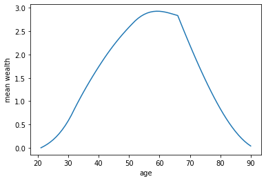

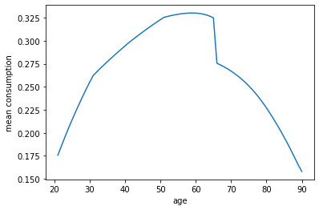

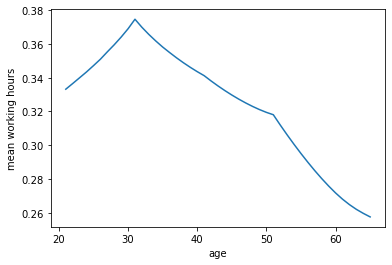

```python
# save results
np.save('cgen',cgen)
np.save('lgen',lgen)
np.save('kgen',kgen)
np.save('earn',earn)
np.save('gearn',gearn)
np.save('gwealth',gwealth)
np.save('ag',ag)

# plotting the averages at different ages
plt.xlabel('age')
plt.ylabel('mean wealth')
plt.plot(range(21,91),kgen/mass)
plt.show()


plt.xlabel('age')
plt.ylabel('mean consumption')
plt.plot(range(21,91),cgen)
plt.show()


plt.xlabel('age')
plt.ylabel('mean working hours')
plt.plot(range(21,66),lgen)
plt.show()
```

This terminate the inner loop and we continue to iterate over the aggregate variable in the outer loop of the program 'AK70_stochastic_income.py' until convergence, which takes place after 29 iterations.

This version: May 12, 2021